# Piecewise Regression with Negative Binomial Type I Error on Real Data using `brms` Custom Family

## Determine reasonable priors for y0

\small

```r
cumulative_count_vs_temp <- list()

for(temp_threshold in 26:45) {
  tmp <- data_ind %>% group_by(male) %>% filter(temp < temp_threshold) %>% summarize(mean = mean(motif_count), sd = sd(motif_count), var = sd^2, cv = sd(motif_count)/mean(motif_count), temp_threshold = temp_threshold)
  mean <- mean(tmp$mean)
  sd <- sd(tmp$mean)
  cumulative_count_vs_temp[[temp_threshold]] <- tmp
  print(paste0("Temp: ", temp_threshold, ", mean: ", mean, ", sd: ", sd))
}
```

```
## [1] "Temp: 26, mean: 63, sd: 89.095454429505"
## [1] "Temp: 27, mean: 126.2, sd: 126.689383927778"
## [1] "Temp: 28, mean: 118.142857142857, sd: 110.701443187564"
## [1] "Temp: 29, mean: 116.071428571429, sd: 111.492312355093"
## [1] "Temp: 30, mean: 116.944444444444, sd: 102.314907407366"
## [1] "Temp: 31, mean: 120.055555555556, sd: 114.670572850134"
## [1] "Temp: 32, mean: 120.257575757576, sd: 104.858697610863"
## [1] "Temp: 33, mean: 120.257575757576, sd: 104.858697610863"
## [1] "Temp: 34, mean: 116.606060606061, sd: 89.5174183151982"
## [1] "Temp: 35, mean: 111.068181818182, sd: 69.0805871808609"
## [1] "Temp: 36, mean: 109.833333333333, sd: 69.568651145629"
## [1] "Temp: 37, mean: 108.231818181818, sd: 69.5451985140861"
## [1] "Temp: 38, mean: 110.348484848485, sd: 68.53139688191"
## [1] "Temp: 39, mean: 111.646176046176, sd: 61.7875535115004"
## [1] "Temp: 40, mean: 112.341666666667, sd: 64.4998385010898"
## [1] "Temp: 41, mean: 113.540928768201, sd: 56.0919858489611"
## [1] "Temp: 42, mean: 116.815308933491, sd: 60.694488706503"
## [1] "Temp: 43, mean: 115.212741046832, sd: 60.7911617164827"
## [1] "Temp: 44, mean: 114.864362152999, sd: 61.2514194145016"
## [1] "Temp: 45, mean: 113.168939393939, sd: 62.0293112972156"
```

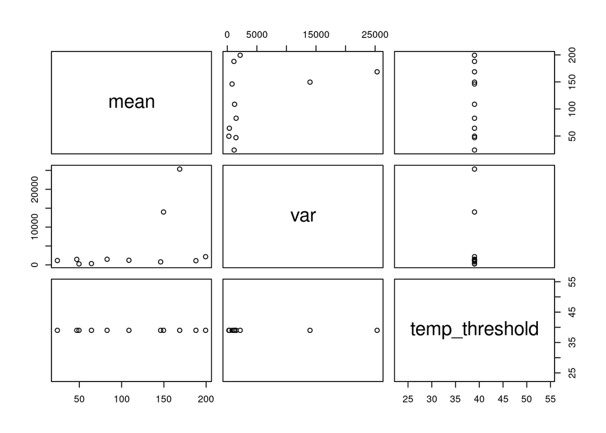

```r
plot_pairs <- pairs(cumulative_count_vs_temp[[39]] %>% select(-c(male, sd, cv)))
```

```r
print(plot_pairs)
```

```r
hist <- ggplot(cumulative_count_vs_temp[[39]], aes(mean)) +
  geom_histogram(bins = 6)

hist_log <- hist + scale_x_log10()

plot_grid <- plot_grid(plotlist = list(hist, hist_log))
```

If using a normal prior, go with `mean = 125` and `sd = 125 * 4 = 500`. However, the data doesn’t seem to follow any real distribution and its at the motif rather than song scale, as a result each male has its own, unknown scaling factor between motifs and songs (i.e. 1/E(# motifs/song) so a flat prior is justifiable.

# Fit Models

- Code derived from `../2023-02-28_fit.real.data.using.nbinom_type1/brms_two.piece_fit.nbionm_type1.Rmd`

## Set up functions, parameters, and results tibble

```r
data_stan <- data_ind %>% rename(y = motif_count, x = temp) %>%
  mutate(male = factor(male))
males <- unique(data_stan$male)
nmales <- length(males)

xmax <- 46 # maximum value for x0
xignore <- 39 # x value above which data is ignored in one_piece model

stan_two_piece_func <- paste0(" real  two_piece(real x, real x0, real y0) {
 real xmax = ", xmax, "; ## paste in value for xmax\n
 real y;

 if(x0 > xmax) {
    y = log(0);
 } else {
    y = y0 * (xmax - fmax(x0, x))/(xmax - x0);
 }
 return(y);
 } ")

stan_one_piece_func <- paste0(" real  one_piece(real y0) {
 return(y0);
 } ")

stan_asymptotic_func <- paste0(" real  asymp(real x, real phi, real y0) {
 real xmax = ", xmax, "; ## paste in value for xmax\n
 return(y0 * (1 - exp( - phi * (xmax - x))) );
 } ")

## Function to drop chains, such as those that get stuck on a suboptimal posterior peak
## Taken from:
remove_chains <- function(brm_fit, chains_to_drop) {
  # brm_fit is the output of brms::brm

  sim <- brm_fit$fit@sim  # Handy shortcut
  sim$samples <- sim$samples[-chains_to_drop]

  # Update the meta-info
  sim$chains <- sim$chains - length(chains_to_drop)
  sim$warmup2 <- sim$warmup2[-chains_to_drop]

  # Add the modified sim back to x
  brm_fit$fit@sim <- sim
  brm_fit
}
## Function to find row(s) in tbl that match criteria

which_tbl_row <- function(filter_male = FALSE, x0_flag = "individual", y0_flag = "individual", disp_flag = "uniform_1", disp_value = 0.01, model = "two_piece", tbl = fit_tbl) {
  which( tbl$filter_male %in% filter_male &
          tbl$x0_flag %in% x0_flag &
          tbl$y0_flag %in% y0_flag &
          tbl$disp_flag %in% disp_flag &
          tbl$disp_value %in% disp_value &
          tbl$model %in% model
          # tbl$sampling_dist %in% sampling &
        )
}
```

## Set up Dataframe for fit results

\small

```r
models <- c("one_piece", "two_piece", "asymptotic")[2:3] #, "one_piece") #, "asymptotic")
sampling_dists <- c("nbinom_type1") ##, "com_poisson") ## lognormal doesn't work since the counts can be 0.
flags_x0 <- c("uniform_1",
              "groups_1", ## this doesn't work with x0_Intercept prior, suggests error in priors
#              "groups_2a",
#              "groups_2b",
              "individual")

flags_y0 <- c("uniform_1", "groups_1", "individual")[3]

values_disp <- switch(1,
                      c(0.01), # 0.125 is a good value
                      c(0.01, 0.1), #, 0.25), # used in exploring model behavior
                      list(0.1, "flat"), #, 0.1, 1) # doesn't work yet
                      c("flat"))

flags_disp <- c("uniform_1", "groups_1", "individual")


## whether to filter males with large disp values estimated using one piece model
filter_male <- c(TRUE, FALSE)

N <- length(data)

fit_tbl <- crossing(model = models,
                    #sampling_dist = sampling_dists,
                    x0_flag = flags_x0,
                    y0_flag = flags_y0,
                    disp_value = values_disp,
                    disp_flag = flags_disp,
                    desc = "NA_character",
                    filter_male = filter_male,
                    #y0_group_list = list(NA), #tbl_tmp, #list(NA),
                    x0_group_list = list(NA),
                    fit = list(NA),
                    llik = list(NA),
                    r_eff = list(NA),
                    loo = list(NA)
                    )
```

### Run fits

\small

```r
run_fits <- FALSE
force_load <- FALSE  #reload fit_tbl even if it already exits
save_fits <- FALSE


if(run_fits) {
  infile_tbl <- NULL
  cur_time <- gsub(" ", "_", Sys.time()) %>% gsub(":", ".", .)
  outfile_tbl <- file.path(output_dir, "tibbles", paste0("fit_tbl_", cur_time, ".Rda"))
} else {
  infile <- last(dir(file.path(output_dir, "tibbles"), "fit_tbl.*"))
  infile_tbl <- file.path(output_dir, "tibbles", infile)
  outfile_tbl <- NULL
}



sampling = "nbinom_type1"
prior_shape_y0 = "flat"

flags_x0_used <- c("individual", "groups_1", "uniform_1") %>% rev()#
flags_y0_used <- c("individual")
values_disp_used <- values_disp
flags_disp_used <- c("individual", "groups_1", "uniform_1")[3] #  |> rev() |> first()
models_used <- c("one_piece", "two_piece", "asymptotic")[2] #c("one_piece", "two_piece") #, "two_piece")
shape_y0_prior <- "flat" # flat or normal

## These males produce bimodial posteriors and interfere with model fitting
## Ideally, we'd do a preliminary analysis without them and then include them later.

male_exclude = c("T235", "T236")

fit_index <- 0

for(male_filter in c(FALSE, TRUE)) {
    for(model in models_used) {

        print(model)
        switch(model,
               two_piece = {
                   ## Note issues in non-convergence are related to bimodality of posterior surface.
                   stan_func <- stan_two_piece_func
                   warmup <- 3000 # floor(3/4 * iter)
                   iter <- warmup + 2000
                   adapt_delta <- 0.99
                   thin <- 4
               },
               one_piece = {
                   stan_func <- stan_one_piece_func
                   warmup <- 2000
                   iter <- warmup + 2000
                   thin <- 4
                   adapt_delta <- 0.7
               },
               asymptotic = {
                   stan_func <- stan_asymptotic_func
                   warmup <- 2000
                   iter <- warmup + 2000
                   thin <- 4
                   adapt_delta <- 0.9
               }

               )
        for(disp_flag in flags_disp_used) {

            print(stan_func)

            for(x0_flag in flags_x0_used) {

                for(y0_flag in flags_y0_used) {

                    ## define variable for labeling figures
                    x0_label <- ifelse(model == "one_piece", "NA", x0_flag)


                    print_get_prior <- TRUE ## reset value
                    print_prior_summary <- TRUE

                    for(disp_value in values_disp_used) {

                        ## used when loading fits
                        fit_index <- fit_index + 1
                        ## Set up variables for saving model and fit

                        desc_short <- paste0("x0: " , x0_label, "; y0: ", y0_flag, "; disp_flag: ", disp_flag, "; disp prior: ", disp_value, "; filter: ", male_filter)
                        desc <- paste0(sampling, "; ", model, "; ", desc_short)

                        filename_desc <- gsub("_", "-", desc) %>%
                            gsub("; ", "_", .) %>%
                            gsub(":? ", "-", .)

                                        #stan_model_name <- sub(filename_desc, "_disp-prior-[0-9.]+_filter", "_filter")
                        stan_model_name <- filename_desc #sub("_disp-prior-[0-9.]+_", "_", filename_desc)

                        curr_row <- which_tbl_row(male_filter,
                                                  x0_flag,
                                                  y0_flag,
                                                  disp_flag,
                                                  disp_value,
                                                  model,
                                                  fit_tbl)

                        fit_tbl[ curr_row, ]$desc <- desc

                        print(desc)

                        if(run_fits) {

                            print("Fitting Models")
                            switch(sampling,
                                   "nbinom_type1"= {
                                       family <- nbinom_type1(link = "identity", link_disp = "identity")
                                       adapt_delta <- adapt_delta #0.95 ## will decreasing value increase ESS? Seems like it
                                       iter <- iter
                                       warmup <- warmup
                                       thin <- thin
                                       n_cores <- 6 ## set to 1 if getting errors from stan in order to see relevant message.
                                       n_chains <- n_cores
                                       stanvar_func <-
                                           stanvar(scode = paste(
                                                       stan_func,
                                                       stan_nbinom_type1, sep = "\n"),
                                                   block = "functions")
                                   }
                                   )

                            ## Refresh data in case x0_group or y0_group are all set to 1
                            data <- data_stan
                            if(male_filter) data <- data %>% filter(!(male %in% male_exclude))

                            males_used <- unique(data$male)

                            if(model == "one_piece") data <- data %>% filter(x < xignore)

                            print("Set flags based on fitted model structure")
                            if(x0_flag %in% c("uniform_1", "groups_1")) data <- mutate(data, x0_group = 1)
                            if(y0_flag %in% c("uniform_1", "groups_1")) data <-mutate(data, y0_group = 1)
                            if(x0_flag %in% c("individual")) data <- mutate(data, x0_group = male)
                            if(y0_flag %in% c("individual")) data <- mutate(data, y0_group = male)

                            ## Note we need to put a tibble into a list because row updates, even if doing
                            ## just one cell, require a list format.
                            ## Haven't defined "y0_group" or "x0_group" variables
                            if(FALSE) {
                                fit_tbl[[curr_row, "x0_group_list"]] <- list(unique(data[, c("male", "x0_group")]))
                                fit_tbl[[curr_row, "y0_group_list"]] <- list(unique(data[, c("male", "y0_group")]))
                            }
```

```r
                            print("Define parameter formulas")
                            x0_form <- switch(x0_flag,
                                              uniform_1 = formula(x0 ~ 0 + Intercept),
                                              uniform_2 = formula(x0 ~ 0 + x0_group),
                                              ## `0 + Intercept` avoids prior being defined on centered data
                                              groups_1 = formula(x0 ~ 0 + Intercept + (1|male)),
                                              groups_2 = formula(x0 ~ 0 + Intercept + (1|male) + x0_group),
                                              individual = formula(x0 ~ 0 + male) ## Do not use 1 + male!
                                              )

                            phi_form <- formula(deparse(x0_form) %>% gsub("x0", "phi", .))

                            y0_form <- switch(y0_flag,
                                              uniform_1 = formula(y0 ~ 0 + Intercept),
                                              ## `0 + Intercept` avoids prior being defined on centered data
                                              uniform_2 = formula(y0 ~ 0 + y0_group),
                                              groups_1 = formula(y0 ~ 0 + Intercept + (1| male)),
                                              groups_2 = formula(y0 ~ 0 + (1| male) + y0_group),
                                              individual = formula(y0 ~ 0 + male)
                                              ## `-1 + ` gives me the error:
                                              ## Warning in parallel::mclapply(1:chains, FUN = callFun, mc.preschedule = FALSE,  :
                                              ##  4 function calls resulted in an error
                                              ## Error in FUN(X[[i]], ...) :
                                              ##  trying to get slot "mode" from an object (class "try-error") that is not an S4 object
                                              ## should I use `0 +` or `-1 +` ?
                                              )

                            threshold_form <- switch(model,
                                                     two_piece = x0_form,
                                                     one_piece = NULL,
                                                     asymptotic = phi_form
                                                     )

                            disp_form <- switch(disp_flag,
                                                uniform_1 = NULL, #formula(disp ~ 1),
                                                groups_1 = formula(disp ~ 0 + Intercept + (1|male)),
                                                individual = formula(disp ~ 0 + male)
                                                )

                            nlform <- switch(model,
                                             two_piece = bf(y ~ two_piece(x, x0, y0), nl = TRUE),
                                             one_piece = bf(y ~ one_piece(y0), nl = TRUE),
                                             asymptotic = bf(y ~ asymp(x, phi, y0), nl = TRUE)
                                             ) +
                                threshold_form +
                                disp_form +
                                y0_form


                            print("Define priors")

                                        # pass disp_value via stanvar argument
                            stanvar_prior <- stanvar(disp_value, name = "disp_value")

                            prior_string <- if(disp_value == "flat") {
                                                "uniform(0, 20)"
                                            } else {
                                        # encode non-flat prior here, which force recompling when disp_value changes
                                        #paste0("exponential(", disp_value, ")")
                                        # pass disp_value via stanvar argument
                                        # Allows disp_value to be changed w/o recompiling
                                                "exponential(disp_value)"
                                            }

                            ## x0 only used in two_piece model
                            x0_prior <- switch(x0_flag,
                                               uniform_1 = NULL,
                                               uniform_2 = NULL,
                                               groups_1 = prior(student_t(3, 0, 66.7), lb = 0, ub = 10, class = "sd", nlpar = "x0"),
                                               groups_2 = NULL,
                                               individual = NULL
                                               )

                            x0_priors <- prior(uniform(32, 44.5), lb = 32, ub = 44.5, nlpar = "x0") + x0_prior

                            phi_priors <- prior(uniform(0.1, 100), lb = 0.01, ub = 17, nlpar = "phi")

                            y0_priors <- switch(prior_shape_y0,
                                                ## Values based on calculations at top of file using `temp_threshold`,
                                                normal = prior(normal(125, 500), nlpar = "y0", lb = 10, ub = 1000),
                                        # flat prior
                                        # - consistent with fact we're working with motifs, not songs
                                        # - avoids bimodal posterior sampling issues with T235 and 236
                                                flat =  prior(uniform(10, 1000), nlpar = "y0", lb = 10, ub = 1000)

                                                )

                            threshold_priors <- switch(model,
                                                       two_piece = x0_priors,
                                                       one_piece = NULL,
                                                       asymptotic = phi_priors
                                                       )
```